# Deliverable 3: main models, additive interaction and mortality burden

Preliminary · Heatwaves, ozone and mortality in Santiago, 2009-2020

Author

Amaru Agüero Jiménez

Published

November 25, 2026

Third deliverable of the data analysis: the main models, the additive interaction between heatwaves and high ozone, the subgroups and the attributable mortality burden. The results are preliminary: they use working definitions that the principal investigator has not confirmed.

| Requested | Where |
| --- | --- |
| Tables of the individual, joint and interaction models | Main models and additive interaction |
| Measures of additive synergy (REOI) | Additive interaction, by cause of death and across the grid of definitions |
| Vulnerability by subgroups | Vulnerability by subgroups: age and sex |
| Mortality burden | Attributable mortality burden |
| Initial figures | The figures of each section |
| Commented scripts | R scripts |

The tables and the figures of this page can be downloaded: each table has an **Excel** button above it, and each figure a **PNG, 600 dpi** button below it. Each part names the scripts and the files behind its tables and figures.

# 1 Main models and additive interaction

*Script: `Code/30_models_main.R`, on the datasets of `Code/21_case_crossover_dataset.R`. Tables: `Output/Tables/models_main_or.csv`, `models_main_interaction.csv`, `models_grid.csv` and `models_ozone_continuous.csv`.*

**WarningPreliminary**

These results use working definitions that the principal investigator has not confirmed: heatwave hw_p95_2d, high ozone o3_idw_gt_p75 (the delivered 24-hour mean, whose limits are shown in the validation of the ozone exposure). They show that the pipeline runs from the death records to the interaction measures and how much the answer depends on the definitions. They are not findings to cite.

## 1.1 Models

For each death the day of death is compared with the control days of the same municipality, year, month and day of the week, by conditional logistic regression, at single-day lags 0 to 3:

| Model | Linear predictor | Reads as |
| --- | --- | --- |
| Heatwave alone | β₁ HW | Odds ratio of death on a heatwave day |
| Ozone alone | β₂ O3high | Odds ratio of death on a high-ozone day |
| Joint | β₁ HW + β₂ O3high | Each exposure adjusted for the other |
| Compound categories | β₁₀ E10 + β₀₁ E01 + β₁₁ E11 | Heatwave only, high ozone only and both, against neither |

Additive interaction comes from the compound model: REOI = OR₁₁ − OR₁₀ − OR₀₁ + 1, AP = REOI / OR₁₁ and S = (OR₁₁ − 1) / [(OR₁₀ − 1) + (OR₀₁ − 1)], with delta-method intervals. The multiplicative ratio OR₁₁ / (OR₁₀ × OR₀₁) is reported next to them.

The days are split at one ozone cut-off, so the reference category (neither) holds every non-heatwave day at or below it. The plan words the reference as ozone at or below the 50th percentile; that version, with three ozone levels, is in the sensitivity analyses.

```r
n_warn_main <- main_or[!is.na(fit_warnings) & fit_warnings != "", .N]
n_warn_grid <- grid[!is.na(fit_warnings) & fit_warnings != "", .N]
not_estimable <- grid[estimable == FALSE, .N]
```

Fits with a warning from the optimiser: 0 rows of the headline tables and 10 cells of the definition grid. Grid cells without deaths in one exposure category, where no odds ratio exists: 28.

## 1.2 Non-accidental mortality, working definitions

```r
headline <- main_or[outcome == "non_accidental" & subgroup == "all"]
headline[, `:=`(Model = model_labels[model], Term = term_labels[term],
                value = ci(or, or_low, or_high, 3))]
kable(dcast(headline, factor(Model, levels = model_labels) + factor(Term, levels = term_labels) ~ lag,
            value.var = "value"),
      col.names = c("Model", "Term", "Lag 0", "Lag 1", "Lag 2", "Lag 3"))
```

Table 1: Odds ratios (95% confidence interval) for non-accidental mortality by lag.

| Model | Term | Lag 0 | Lag 1 | Lag 2 | Lag 3 |
| --- | --- | --- | --- | --- | --- |
| Heatwave alone | Heatwave | 1.075 (1.051 to 1.100) | 1.063 (1.040 to 1.088) | 1.034 (1.011 to 1.058) | 1.022 (0.999 to 1.046) |
| Ozone alone | High ozone | 1.041 (1.025 to 1.057) | 1.033 (1.017 to 1.049) | 1.010 (0.995 to 1.026) | 1.001 (0.986 to 1.016) |
| Joint | Heatwave | 1.064 (1.040 to 1.089) | 1.055 (1.030 to 1.080) | 1.032 (1.009 to 1.057) | 1.023 (0.999 to 1.047) |
| Joint | High ozone | 1.031 (1.015 to 1.047) | 1.025 (1.009 to 1.041) | 1.006 (0.990 to 1.021) | 0.998 (0.982 to 1.013) |
| Compound categories | Heatwave only (E10) | 1.067 (1.032 to 1.104) | 1.051 (1.016 to 1.087) | 1.021 (0.987 to 1.057) | 1.007 (0.973 to 1.042) |
| Compound categories | High ozone only (E01) | 1.032 (1.015 to 1.049) | 1.024 (1.007 to 1.041) | 1.003 (0.987 to 1.020) | 0.994 (0.978 to 1.011) |
| Compound categories | Heatwave and high ozone (E11) | 1.096 (1.064 to 1.128) | 1.083 (1.052 to 1.116) | 1.046 (1.015 to 1.077) | 1.031 (1.001 to 1.062) |

```r
counts <- unique(headline[, .(lag, deaths, deaths_e00, deaths_e10, deaths_e01, deaths_e11)])
kable(counts, format.args = list(big.mark = ","),
      col.names = c("Lag", "Deaths", "Neither (E00)", "Heatwave only (E10)",
                    "High ozone only (E01)", "Both (E11)"))
```

Table 2: Deaths by exposure category on the lagged day, non-accidental mortality.

| Lag | Deaths | Neither (E00) | Heatwave only (E10) | High ozone only (E01) | Both (E11) |
| --- | --- | --- | --- | --- | --- |
| 0 | 135,359 | 95,499 | 4,919 | 27,597 | 7,344 |
| 1 | 135,359 | 95,667 | 4,830 | 27,558 | 7,304 |
| 2 | 135,359 | 96,098 | 4,713 | 27,378 | 7,170 |
| 3 | 135,359 | 96,201 | 4,699 | 27,376 | 7,083 |

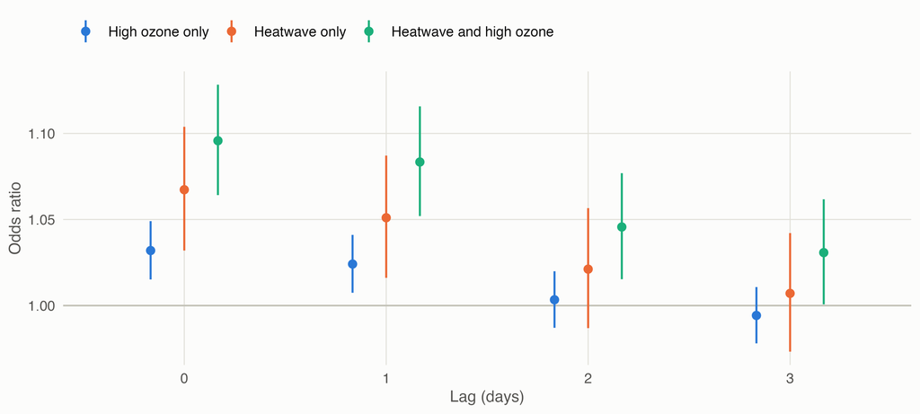

Figure 1: Odds ratios of non-accidental death by exposure category and lag, compound model. Bars are 95% confidence intervals.

```r
compound <- headline[model == "compound"]
compound[, category := factor(c(e10 = "Heatwave only", e01 = "High ozone only",
                                e11 = "Heatwave and high ozone")[term],
                              levels = c("High ozone only", "Heatwave only", "Heatwave and high ozone"))]
ggplot(compound, aes(factor(lag), or, colour = category)) +
  geom_hline(yintercept = 1, colour = ink$axis) +
  geom_pointrange(aes(ymin = or_low, ymax = or_high), position = position_dodge(width = 0.5),
                  linewidth = 0.6, size = 0.35) +
  scale_colour_manual(values = colour_compound[levels(compound$category)]) +
  labs(x = "Lag (days)", y = "Odds ratio", colour = NULL)
```

```r
h0 <- headline[lag == 0 & model == "compound"]
r_main <- main_int[outcome == "non_accidental" & subgroup == "all" & measure == "REOI"]
```

With the working definitions, on the day of exposure the odds of non-accidental death are 1.07 (1.03 to 1.10) times higher on heatwave-only days, 1.03 (1.02 to 1.05) on high-ozone-only days and 1.10 (1.06 to 1.13) on days with both, each against days with neither. The associations weaken with the lag. The joint odds ratio is close to what the two single excesses add up to: the REOI interval includes zero at every lag (lag 0: -0.004 (-0.052 to 0.045); lag 1: 0.008 (-0.040 to 0.056); lag 2: 0.021 (-0.026 to 0.068); lag 3: 0.029 (-0.017 to 0.076)).

### 1.2.1 Additive interaction

```r
interaction <- main_int[outcome %in% c("non_accidental", "cardiopulmonary") & subgroup == "all"]
interaction[, value := ci_measure(measure, estimate, low, high)]
interaction[, Outcome := cause_labels[outcome]]
kable(dcast(interaction, factor(Outcome, levels = cause_labels[1:2]) +
              factor(measure, levels = c("REOI", "AP", "S", "multiplicative ratio")) ~ lag,
            value.var = "value"),
      col.names = c("Outcome", "Measure", "Lag 0", "Lag 1", "Lag 2", "Lag 3"))
```

Table 3: Interaction between heatwave and high ozone, non-accidental and cardiopulmonary mortality. REOI and AP have null value 0; S and the multiplicative ratio have null value 1.

| Outcome | Measure | Lag 0 | Lag 1 | Lag 2 | Lag 3 |
| --- | --- | --- | --- | --- | --- |
| Non-accidental | REOI | -0.004 (-0.052 to 0.045) | 0.008 (-0.040 to 0.056) | 0.021 (-0.026 to 0.068) | 0.029 (-0.017 to 0.076) |
| Non-accidental | AP | -0.003 (-0.047 to 0.041) | 0.008 (-0.037 to 0.052) | 0.020 (-0.024 to 0.065) | 0.029 (-0.016 to 0.073) |
| Non-accidental | S | 0.965 (0.589 to 1.581) | 1.110 (0.599 to 2.057) | 1.860 (0.351 to 9.862) | 22.899 (interval not informative) |
| Non-accidental | multiplicative ratio | 0.995 (0.951 to 1.041) | 1.007 (0.962 to 1.053) | 1.021 (0.975 to 1.068) | 1.029 (0.983 to 1.078) |
| Cardiopulmonary | REOI | -0.031 (-0.108 to 0.047) | -0.016 (-0.094 to 0.062) | 0.024 (-0.051 to 0.099) | 0.043 (-0.032 to 0.117) |
| Cardiopulmonary | AP | -0.029 (-0.103 to 0.045) | -0.015 (-0.088 to 0.058) | 0.023 (-0.049 to 0.095) | 0.042 (-0.030 to 0.113) |
| Cardiopulmonary | S | 0.646 (0.218 to 1.920) | 0.832 (0.346 to 1.999) | 3.264 (interval not informative) | -2.591 (interval not informative) |
| Cardiopulmonary | multiplicative ratio | 0.971 (0.902 to 1.044) | 0.985 (0.916 to 1.059) | 1.024 (0.951 to 1.102) | 1.043 (0.969 to 1.123) |

## 1.3 By cause of death

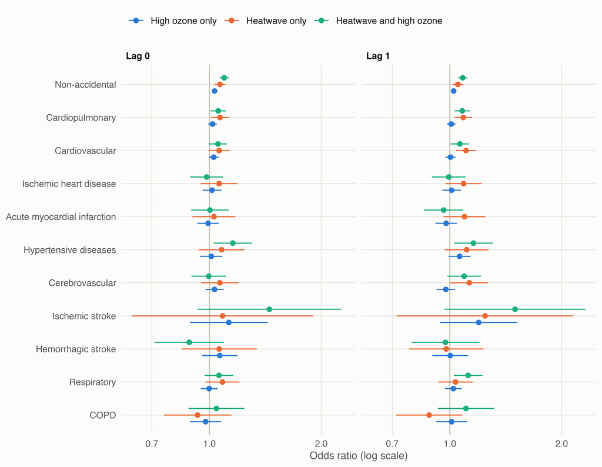

Figure 2: Odds ratios by cause of death and exposure category, lags 0 and 1, compound model. Bars are 95% confidence intervals.

```r
causes <- main_or[subgroup == "all" & model == "compound" & lag %in% 0:1]
causes[, category := factor(c(e10 = "Heatwave only", e01 = "High ozone only",
                              e11 = "Heatwave and high ozone")[term],
                            levels = c("High ozone only", "Heatwave only", "Heatwave and high ozone"))]
causes[, cause := factor(cause_labels[outcome], levels = rev(cause_labels))]
ggplot(causes, aes(or, cause, colour = category)) +
  geom_vline(xintercept = 1, colour = ink$axis) +
  geom_pointrange(aes(xmin = or_low, xmax = or_high), position = position_dodge(width = 0.6),
                  linewidth = 0.5, size = 0.3) +
  facet_wrap(~paste("Lag", lag)) +
  scale_colour_manual(values = colour_compound[levels(causes$category)]) +
  scale_x_log10() +
  labs(x = "Odds ratio (log scale)", y = NULL, colour = NULL)
```

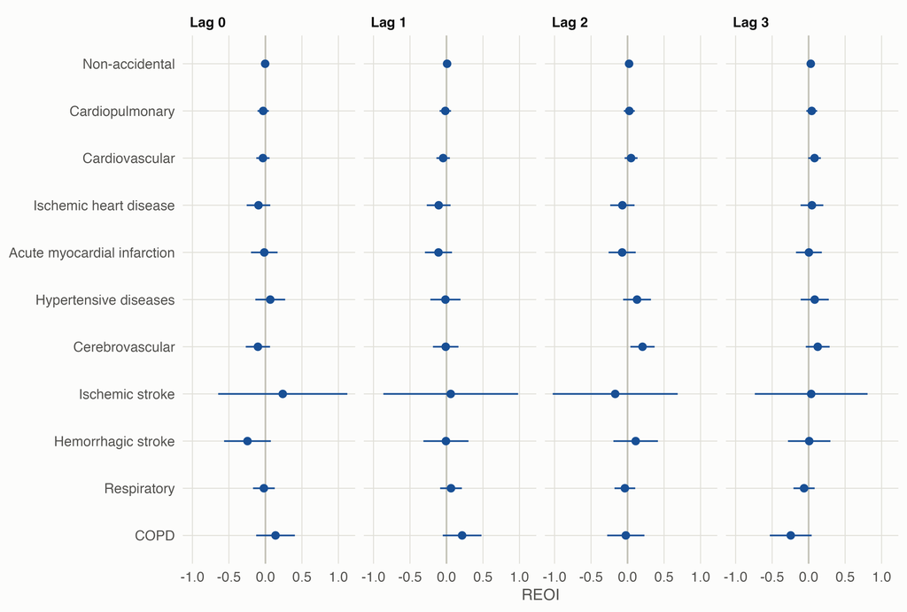

Figure 3: Relative excess odds due to interaction (REOI) by cause of death and lag. Bars are 95% confidence intervals; zero means no additive interaction.

```r
reoi <- main_int[subgroup == "all" & measure == "REOI"]
reoi[, cause := factor(cause_labels[outcome], levels = rev(cause_labels))]
ggplot(reoi, aes(estimate, cause)) +
  geom_vline(xintercept = 0, colour = ink$axis) +
  geom_pointrange(aes(xmin = low, xmax = high), colour = ramp_blue[6], linewidth = 0.5, size = 0.3) +
  facet_wrap(~paste("Lag", lag), nrow = 1) +
  labs(x = "REOI", y = NULL)
```

```r
cause_table <- merge(
  dcast(main_or[subgroup == "all" & model == "compound"], outcome + lag + deaths + deaths_e11 ~ term,
        value.var = c("or", "or_low", "or_high")),
  main_int[subgroup == "all" & measure == "REOI", .(outcome, lag, reoi = estimate, reoi_low = low, reoi_high = high)],
  by = c("outcome", "lag")
)
cause_table <- cause_table[, .(
  Cause = factor(cause_labels[outcome], levels = cause_labels), Lag = lag, Deaths = deaths,
  `Deaths in E11` = deaths_e11,
  `Heatwave only` = ci(or_e10, or_low_e10, or_high_e10),
  `High ozone only` = ci(or_e01, or_low_e01, or_high_e01),
  `Both` = ci(or_e11, or_low_e11, or_high_e11),
  REOI = ci(reoi, reoi_low, reoi_high)
)][order(Cause, Lag)]
kableExtra::scroll_box(
  kableExtra::kable_styling(kable(cause_table, format = "html", format.args = list(big.mark = ",")),
                            bootstrap_options = c("striped", "condensed"), font_size = 12),
  height = "420px"
)
```

Table 4: Compound model by cause of death: deaths, odds ratios and REOI with 95% confidence intervals.

| Cause | Lag | Deaths | Deaths in E11 | Heatwave only | High ozone only | Both | REOI |
| --- | --- | --- | --- | --- | --- | --- | --- |
| Non-accidental | 0 | 135,359 | 7,344 | 1.07 (1.03 to 1.10) | 1.03 (1.02 to 1.05) | 1.10 (1.06 to 1.13) | -0.00 (-0.05 to 0.04) |
| Non-accidental | 1 | 135,359 | 7,304 | 1.05 (1.02 to 1.09) | 1.02 (1.01 to 1.04) | 1.08 (1.05 to 1.12) | 0.01 (-0.04 to 0.06) |
| Non-accidental | 2 | 135,359 | 7,170 | 1.02 (0.99 to 1.06) | 1.00 (0.99 to 1.02) | 1.05 (1.02 to 1.08) | 0.02 (-0.03 to 0.07) |
| Non-accidental | 3 | 135,359 | 7,083 | 1.01 (0.97 to 1.04) | 0.99 (0.98 to 1.01) | 1.03 (1.00 to 1.06) | 0.03 (-0.02 to 0.08) |
| Cardiopulmonary | 0 | 52,012 | 2,807 | 1.07 (1.01 to 1.13) | 1.02 (0.99 to 1.05) | 1.06 (1.01 to 1.11) | -0.03 (-0.11 to 0.05) |
| Cardiopulmonary | 1 | 52,012 | 2,794 | 1.09 (1.03 to 1.15) | 1.01 (0.98 to 1.04) | 1.08 (1.03 to 1.13) | -0.02 (-0.09 to 0.06) |
| Cardiopulmonary | 2 | 52,012 | 2,745 | 1.02 (0.96 to 1.08) | 0.99 (0.97 to 1.02) | 1.03 (0.99 to 1.09) | 0.02 (-0.05 to 0.10) |
| Cardiopulmonary | 3 | 52,012 | 2,725 | 1.00 (0.94 to 1.05) | 0.99 (0.97 to 1.02) | 1.03 (0.98 to 1.08) | 0.04 (-0.03 to 0.12) |
| Cardiovascular | 0 | 38,545 | 1,991 | 1.06 (1.00 to 1.13) | 1.03 (1.00 to 1.06) | 1.05 (1.00 to 1.11) | -0.03 (-0.12 to 0.06) |
| Cardiovascular | 1 | 38,545 | 1,963 | 1.11 (1.04 to 1.18) | 1.00 (0.97 to 1.04) | 1.06 (1.01 to 1.13) | -0.05 (-0.14 to 0.05) |
| Cardiovascular | 2 | 38,545 | 1,983 | 1.02 (0.95 to 1.09) | 0.99 (0.96 to 1.02) | 1.05 (1.00 to 1.11) | 0.05 (-0.04 to 0.14) |
| Cardiovascular | 3 | 38,545 | 1,955 | 0.98 (0.92 to 1.04) | 0.98 (0.95 to 1.02) | 1.05 (0.99 to 1.11) | 0.08 (-0.01 to 0.17) |
| Ischemic heart disease | 0 | 11,179 | 574 | 1.06 (0.95 to 1.19) | 1.02 (0.96 to 1.08) | 0.98 (0.89 to 1.09) | -0.10 (-0.26 to 0.07) |
| Ischemic heart disease | 1 | 11,179 | 557 | 1.09 (0.97 to 1.22) | 1.01 (0.95 to 1.07) | 0.99 (0.89 to 1.10) | -0.11 (-0.27 to 0.06) |
| Ischemic heart disease | 2 | 11,179 | 579 | 1.11 (0.99 to 1.24) | 1.00 (0.94 to 1.06) | 1.04 (0.94 to 1.15) | -0.07 (-0.24 to 0.10) |
| Ischemic heart disease | 3 | 11,179 | 569 | 0.96 (0.85 to 1.08) | 1.01 (0.95 to 1.07) | 1.01 (0.91 to 1.12) | 0.05 (-0.11 to 0.20) |
| Acute myocardial infarction | 0 | 8,403 | 449 | 1.03 (0.90 to 1.17) | 0.99 (0.93 to 1.06) | 1.00 (0.89 to 1.13) | -0.02 (-0.20 to 0.17) |
| Acute myocardial infarction | 1 | 8,403 | 414 | 1.10 (0.96 to 1.25) | 0.98 (0.91 to 1.04) | 0.96 (0.85 to 1.09) | -0.11 (-0.30 to 0.08) |
| Acute myocardial infarction | 2 | 8,403 | 436 | 1.06 (0.93 to 1.21) | 1.02 (0.96 to 1.09) | 1.01 (0.90 to 1.14) | -0.07 (-0.26 to 0.11) |
| Acute myocardial infarction | 3 | 8,403 | 409 | 0.95 (0.83 to 1.09) | 1.02 (0.96 to 1.09) | 0.98 (0.87 to 1.10) | 0.00 (-0.17 to 0.18) |
| Hypertensive diseases | 0 | 7,737 | 451 | 1.08 (0.94 to 1.24) | 1.01 (0.94 to 1.08) | 1.16 (1.03 to 1.30) | 0.07 (-0.14 to 0.27) |
| Hypertensive diseases | 1 | 7,737 | 437 | 1.11 (0.97 to 1.27) | 1.06 (0.99 to 1.14) | 1.16 (1.03 to 1.31) | -0.01 (-0.22 to 0.19) |
| Hypertensive diseases | 2 | 7,737 | 450 | 0.99 (0.86 to 1.14) | 0.96 (0.90 to 1.03) | 1.09 (0.97 to 1.23) | 0.13 (-0.06 to 0.32) |
| Hypertensive diseases | 3 | 7,737 | 429 | 1.00 (0.87 to 1.15) | 1.00 (0.94 to 1.08) | 1.08 (0.96 to 1.22) | 0.08 (-0.11 to 0.28) |
| Cerebrovascular | 0 | 11,421 | 529 | 1.07 (0.95 to 1.20) | 1.03 (0.98 to 1.09) | 1.00 (0.89 to 1.11) | -0.10 (-0.27 to 0.06) |
| Cerebrovascular | 1 | 11,421 | 576 | 1.13 (1.00 to 1.27) | 0.98 (0.92 to 1.03) | 1.09 (0.98 to 1.21) | -0.01 (-0.19 to 0.16) |
| Cerebrovascular | 2 | 11,421 | 591 | 0.97 (0.86 to 1.10) | 0.94 (0.89 to 1.00) | 1.12 (1.01 to 1.24) | 0.20 (0.04 to 0.37) |
| Cerebrovascular | 3 | 11,421 | 567 | 0.98 (0.87 to 1.11) | 0.96 (0.91 to 1.02) | 1.07 (0.96 to 1.18) | 0.12 (-0.04 to 0.29) |
| Ischemic stroke | 0 | 571 | 33 | 1.08 (0.62 to 1.90) | 1.13 (0.89 to 1.44) | 1.45 (0.93 to 2.26) | 0.24 (-0.65 to 1.12) |
| Ischemic stroke | 1 | 571 | 34 | 1.24 (0.72 to 2.15) | 1.20 (0.94 to 1.52) | 1.50 (0.97 to 2.32) | 0.06 (-0.86 to 0.98) |
| Ischemic stroke | 2 | 571 | 26 | 1.33 (0.80 to 2.22) | 0.95 (0.74 to 1.22) | 1.11 (0.68 to 1.81) | -0.17 (-1.03 to 0.69) |
| Ischemic stroke | 3 | 571 | 33 | 1.02 (0.58 to 1.79) | 1.13 (0.89 to 1.45) | 1.19 (0.77 to 1.83) | 0.04 (-0.74 to 0.81) |
| Hemorrhagic stroke | 0 | 3,013 | 127 | 1.06 (0.84 to 1.34) | 1.07 (0.96 to 1.19) | 0.88 (0.71 to 1.09) | -0.25 (-0.57 to 0.07) |
| Hemorrhagic stroke | 1 | 3,013 | 137 | 0.98 (0.78 to 1.23) | 1.00 (0.90 to 1.12) | 0.97 (0.79 to 1.20) | -0.01 (-0.32 to 0.30) |
| Hemorrhagic stroke | 2 | 3,013 | 141 | 0.94 (0.73 to 1.20) | 0.88 (0.79 to 0.99) | 0.93 (0.76 to 1.15) | 0.11 (-0.19 to 0.42) |
| Hemorrhagic stroke | 3 | 3,013 | 130 | 0.89 (0.70 to 1.14) | 0.96 (0.86 to 1.07) | 0.86 (0.70 to 1.06) | 0.01 (-0.28 to 0.30) |
| Respiratory | 0 | 13,467 | 816 | 1.08 (0.98 to 1.20) | 1.00 (0.95 to 1.05) | 1.06 (0.97 to 1.16) | -0.02 (-0.17 to 0.13) |
| Respiratory | 1 | 13,467 | 831 | 1.04 (0.93 to 1.15) | 1.02 (0.97 to 1.08) | 1.12 (1.02 to 1.22) | 0.06 (-0.09 to 0.21) |
| Respiratory | 2 | 13,467 | 762 | 1.02 (0.91 to 1.13) | 1.01 (0.96 to 1.06) | 0.99 (0.90 to 1.08) | -0.04 (-0.18 to 0.11) |
| Respiratory | 3 | 13,467 | 770 | 1.04 (0.94 to 1.16) | 1.02 (0.96 to 1.07) | 1.00 (0.91 to 1.09) | -0.06 (-0.21 to 0.08) |
| COPD | 0 | 3,925 | 208 | 0.93 (0.75 to 1.15) | 0.98 (0.89 to 1.08) | 1.04 (0.88 to 1.24) | 0.14 (-0.13 to 0.40) |
| COPD | 1 | 3,925 | 214 | 0.88 (0.72 to 1.08) | 1.01 (0.92 to 1.11) | 1.11 (0.93 to 1.31) | 0.21 (-0.05 to 0.48) |
| COPD | 2 | 3,925 | 194 | 0.94 (0.76 to 1.15) | 1.00 (0.91 to 1.10) | 0.92 (0.77 to 1.09) | -0.02 (-0.28 to 0.23) |
| COPD | 3 | 3,925 | 187 | 1.14 (0.94 to 1.39) | 1.04 (0.94 to 1.14) | 0.94 (0.78 to 1.12) | -0.24 (-0.53 to 0.04) |

## 1.4 Vulnerability by subgroups: age and sex

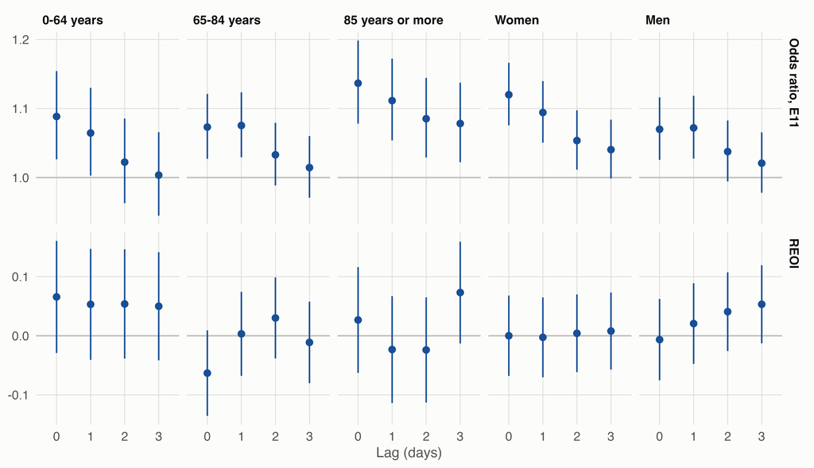

Figure 4: Non-accidental mortality by age group and sex: odds ratio of days with both exposures (E11) and REOI, by lag. Bars are 95% confidence intervals.

```r
sub_or <- main_or[outcome == "non_accidental" & subgroup != "all" & model == "compound" & term == "e11",
                  .(subgroup, lag, measure = "Odds ratio, E11", estimate = or,
                    low = or_low, high = or_high, null = 1)]
sub_reoi <- main_int[outcome == "non_accidental" & subgroup != "all" & measure == "REOI",
                     .(subgroup, lag, measure = "REOI", estimate, low, high, null = 0)]
subgroups <- rbind(sub_or, sub_reoi)
subgroups[, subgroup := factor(subgroup, levels = c("0-64", "65-84", "85+", "female", "male"),
                               labels = c("0-64 years", "65-84 years", "85 years or more", "Women", "Men"))]
ggplot(subgroups, aes(factor(lag), estimate)) +
  geom_hline(aes(yintercept = null), colour = ink$axis) +
  geom_pointrange(aes(ymin = low, ymax = high), colour = ramp_blue[6], linewidth = 0.5, size = 0.3) +
  facet_grid(measure ~ subgroup, scales = "free_y") +
  labs(x = "Lag (days)", y = NULL)
```

```r
e11 <- main_or[outcome == "non_accidental" & model == "compound" & term == "e11" & subgroup != "all",
               .(subgroup, lag, log_or, se)]
pairs <- list(c("0-64", "65-84"), c("0-64", "85+"), c("female", "male"))
tests <- rbindlist(lapply(pairs, function(pair) {
  d <- merge(e11[subgroup == pair[1]], e11[subgroup == pair[2]], by = "lag", suffixes = c("_a", "_b"))
  d[, .(comparison = paste(pair[2], "against", pair[1]), lag,
        ratio_of_odds_ratios = exp(log_or_b - log_or_a),
        z = (log_or_b - log_or_a) / sqrt(se_a^2 + se_b^2))][
    , p_value := 2 * pnorm(-abs(z))]
}))
kable(tests, digits = c(0, 0, 3, 2, 3),
      col.names = c("Comparison", "Lag", "Ratio of odds ratios", "z", "p"))
```

Table 5: Difference between subgroups in the log odds ratio of the compound exposure (E11): two-sample z-test against the first subgroup of each pair.

| Comparison | Lag | Ratio of odds ratios | z | p |
| --- | --- | --- | --- | --- |
| 65-84 against 0-64 | 0 | 0.986 | -0.38 | 0.705 |
| 65-84 against 0-64 | 1 | 1.010 | 0.27 | 0.788 |
| 65-84 against 0-64 | 2 | 1.010 | 0.27 | 0.785 |
| 65-84 against 0-64 | 3 | 1.011 | 0.28 | 0.776 |
| 85+ against 0-64 | 0 | 1.044 | 1.08 | 0.282 |
| 85+ against 0-64 | 1 | 1.044 | 1.06 | 0.291 |
| 85+ against 0-64 | 2 | 1.062 | 1.46 | 0.144 |
| 85+ against 0-64 | 3 | 1.074 | 1.75 | 0.080 |
| male against female | 0 | 0.955 | -1.53 | 0.126 |
| male against female | 1 | 0.980 | -0.68 | 0.494 |
| male against female | 2 | 0.985 | -0.51 | 0.611 |
| male against female | 3 | 0.981 | -0.63 | 0.530 |

## 1.5 Across the grid of definitions

*Script: `Code/30_models_main.R`. Table: `Output/Tables/models_grid.csv`.*

The compound model was fitted for every combination of the 15 heatwave definitions, the three ozone series, the two interpolation methods and the three cut-offs, at each lag. The figure shows the REOI for non-accidental mortality with the IDW series; a dot marks the cells whose 95% interval excludes zero. The colour scale stops at ±0.15: the few cells beyond it, all in the rarest heatwave definitions, are drawn at the limit.

```r
g <- grid[outcome == "non_accidental" & grepl("_idw_", ozone) & estimable == TRUE]
g[, series := factor(sub("_idw_gt_p[0-9]+$", "", ozone), levels = c("o3", "o3obs", "o3mda8"),
                     labels = c("Delivered 24 h", "Rebuilt 24 h", "Rebuilt MDA8"))]
g[, cutoff := paste0("> P", sub(".*_gt_p", "", ozone))]
g[, heatwave := factor(heatwave, levels = rev(unique(grid$heatwave)))]
g[, excludes_zero := low_reoi > 0 | high_reoi < 0]
limit <- 0.15
ggplot(g, aes(cutoff, heatwave, fill = estimate_reoi)) +
  geom_tile(colour = ink$surface, linewidth = 0.8) +
  geom_point(data = g[excludes_zero == TRUE], size = 1.2, colour = ink$primary) +
  facet_grid(paste("Lag", lag) ~ series) +
  scale_fill_gradient2(low = diverging[["low"]], mid = diverging[["mid"]], high = diverging[["high"]],
                       midpoint = 0, limits = c(-limit, limit), oob = scales::squish, name = "REOI") +
  labs(x = "Ozone cut-off (municipality percentile)", y = NULL) +
  theme(panel.grid.major = element_blank(), legend.position = "right",
        legend.justification = "center")
```

[figure not shown]

Figure 5: REOI for non-accidental mortality across heatwave definitions (rows) and ozone definitions (columns), by lag, IDW series.

```r
grid_summary <- grid[estimable == TRUE, .(
  cells = .N, median_reoi = median(estimate_reoi), min_reoi = min(estimate_reoi),
  max_reoi = max(estimate_reoi), above_zero = sum(low_reoi > 0), below_zero = sum(high_reoi < 0)
), keyby = .(outcome, lag)]
grid_summary[, outcome := cause_labels[outcome]]
kable(grid_summary, digits = 3,
      col.names = c("Outcome", "Lag", "Cells", "Median REOI", "Lowest REOI", "Highest REOI",
                    "Interval above zero", "Interval below zero"))
```

Table 6: Definition grid, summary by outcome and lag: number of fitted cells, range of the REOI and cells whose 95% interval excludes zero.

| Outcome | Lag | Cells | Median REOI | Lowest REOI | Highest REOI | Interval above zero | Interval below zero |
| --- | --- | --- | --- | --- | --- | --- | --- |
| Cardiopulmonary | 0 | 266 | -0.015 | -1.205 | 0.343 | 2 | 7 |
| Cardiopulmonary | 1 | 266 | 0.001 | -10.881 | 0.498 | 12 | 7 |
| Cardiopulmonary | 2 | 266 | 0.035 | -0.604 | 0.475 | 44 | 1 |
| Cardiopulmonary | 3 | 266 | 0.041 | -4.405 | 0.652 | 55 | 2 |
| Non-accidental | 0 | 267 | -0.009 | -0.669 | 0.635 | 1 | 8 |
| Non-accidental | 1 | 267 | 0.009 | -0.791 | 0.321 | 4 | 0 |
| Non-accidental | 2 | 267 | 0.034 | -0.244 | 0.387 | 71 | 0 |
| Non-accidental | 3 | 267 | 0.036 | -1.753 | 0.482 | 97 | 3 |

With 2132 cells and no correction for multiple comparisons, about 107 intervals would exclude zero by chance alone. The full grid is in `Output/Tables/models_grid.csv`.

### 1.5.1 Where the positive cells are

```r
by_threshold <- grid[estimable == TRUE & outcome == "non_accidental", .(
  cells = .N, above_zero_pct = 100 * mean(low_reoi > 0), median_reoi = median(estimate_reoi)
), by = .(threshold = sub("^hw_(.*)_[0-9]d$", "\\1", heatwave), lag)]
by_threshold[, threshold := factor(threshold, levels = c("p90", "p95", "p99", "30c", "ehf"),
                                   labels = c("> P90", "> P95", "> P99", "> 30 °C", "EHF > 0"))]
kable(dcast(by_threshold, threshold ~ lag, value.var = c("above_zero_pct", "median_reoi")),
      digits = c(0, 0, 0, 0, 0, 3, 3, 3, 3),
      col.names = c("Heatwave threshold", paste("% above zero, lag", 0:3), paste("Median REOI, lag", 0:3)))
```

Table 7: Non-accidental mortality: share of grid cells (%) whose REOI interval lies above zero, by heatwave threshold and lag, with the median REOI.

| Heatwave threshold | % above zero, lag 0 | % above zero, lag 1 | % above zero, lag 2 | % above zero, lag 3 | Median REOI, lag 0 | Median REOI, lag 1 | Median REOI, lag 2 | Median REOI, lag 3 |
| --- | --- | --- | --- | --- | --- | --- | --- | --- |
| > P90 | 0 | 0 | 33 | 20 | -0.009 | 0.009 | 0.034 | 0.032 |
| > P95 | 0 | 2 | 11 | 0 | -0.017 | 0.010 | 0.036 | 0.015 |
| > P99 | 2 | 0 | 0 | 2 | -0.006 | -0.035 | 0.004 | 0.014 |
| > 30 °C | 0 | 0 | 50 | 85 | -0.010 | 0.009 | 0.039 | 0.053 |
| EHF > 0 | 0 | 6 | 37 | 72 | -0.004 | 0.016 | 0.035 | 0.047 |

## 1.6 Ozone as a continuous exposure

*Script: `Code/30_models_main.R`. Table: `Output/Tables/models_ozone_continuous.csv`.*

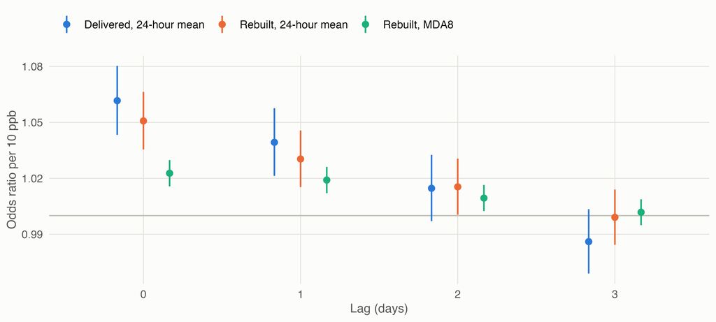

Figure 6: Odds ratio of non-accidental death per 10 ppb of ozone, by ozone series and lag, IDW, adjusted for the working heatwave indicator. Bars are 95% confidence intervals.

```r
cont <- continuous[outcome == "non_accidental" & adjustment != "none" & grepl("_idw$", series)]
cont[, series := factor(sub("_idw$", "", series), levels = c("o3", "o3obs", "o3mda8"),
                        labels = names(colour_series))]
ggplot(cont, aes(factor(lag), or, colour = series)) +
  geom_hline(yintercept = 1, colour = ink$axis) +
  geom_pointrange(aes(ymin = or_low, ymax = or_high), position = position_dodge(width = 0.5),
                  linewidth = 0.6, size = 0.35) +
  scale_colour_manual(values = colour_series) +
  labs(x = "Lag (days)", y = "Odds ratio per 10 ppb", colour = NULL)
```

```r
cont_table <- copy(continuous)[, value := ci(or, or_low, or_high, 3)]
cont_table[, outcome := cause_labels[outcome]]
kableExtra::scroll_box(
  kableExtra::kable_styling(
    kable(dcast(cont_table, outcome + series + adjustment ~ lag, value.var = "value"), format = "html",
          col.names = c("Outcome", "Ozone series", "Adjusted for", "Lag 0", "Lag 1", "Lag 2", "Lag 3")),
    bootstrap_options = c("striped", "condensed"), font_size = 12),
  height = "380px"
)
```

Table 8: Odds ratio per 10 ppb of ozone (95% confidence interval), by outcome, series, adjustment and lag.

| Outcome | Ozone series | Adjusted for | Lag 0 | Lag 1 | Lag 2 | Lag 3 |
| --- | --- | --- | --- | --- | --- | --- |
| Cardiopulmonary | o3_idw | hw_p95_2d | 1.054 (1.025 to 1.084) | 1.013 (0.985 to 1.042) | 0.998 (0.970 to 1.026) | 0.976 (0.949 to 1.004) |
| Cardiopulmonary | o3_idw | none | 1.061 (1.032 to 1.090) | 1.026 (0.998 to 1.054) | 1.003 (0.976 to 1.031) | 0.980 (0.954 to 1.008) |
| Cardiopulmonary | o3_ok | hw_p95_2d | 1.052 (1.024 to 1.081) | 1.016 (0.989 to 1.043) | 0.993 (0.967 to 1.021) | 0.974 (0.948 to 1.001) |
| Cardiopulmonary | o3_ok | none | 1.059 (1.031 to 1.087) | 1.027 (1.001 to 1.055) | 0.999 (0.973 to 1.025) | 0.979 (0.953 to 1.005) |
| Cardiopulmonary | o3mda8_idw | hw_p95_2d | 1.020 (1.008 to 1.031) | 1.011 (1.000 to 1.022) | 1.006 (0.995 to 1.017) | 1.004 (0.993 to 1.015) |
| Cardiopulmonary | o3mda8_idw | none | 1.023 (1.012 to 1.034) | 1.017 (1.006 to 1.028) | 1.008 (0.997 to 1.019) | 1.005 (0.995 to 1.016) |
| Cardiopulmonary | o3mda8_ok | hw_p95_2d | 1.022 (1.010 to 1.033) | 1.012 (1.001 to 1.024) | 1.007 (0.996 to 1.019) | 1.004 (0.993 to 1.016) |
| Cardiopulmonary | o3mda8_ok | none | 1.025 (1.014 to 1.036) | 1.018 (1.008 to 1.029) | 1.010 (0.999 to 1.021) | 1.006 (0.995 to 1.016) |
| Cardiopulmonary | o3obs_idw | hw_p95_2d | 1.048 (1.023 to 1.073) | 1.013 (0.989 to 1.037) | 1.006 (0.982 to 1.030) | 0.998 (0.974 to 1.022) |
| Cardiopulmonary | o3obs_idw | none | 1.054 (1.030 to 1.078) | 1.026 (1.003 to 1.050) | 1.011 (0.988 to 1.034) | 1.001 (0.978 to 1.024) |
| Cardiopulmonary | o3obs_ok | hw_p95_2d | 1.050 (1.025 to 1.076) | 1.019 (0.995 to 1.044) | 1.002 (0.978 to 1.026) | 0.999 (0.976 to 1.024) |
| Cardiopulmonary | o3obs_ok | none | 1.056 (1.032 to 1.081) | 1.033 (1.009 to 1.056) | 1.007 (0.984 to 1.030) | 1.003 (0.980 to 1.026) |
| Non-accidental | o3_idw | hw_p95_2d | 1.062 (1.043 to 1.080) | 1.039 (1.021 to 1.058) | 1.015 (0.997 to 1.033) | 0.986 (0.969 to 1.003) |
| Non-accidental | o3_idw | none | 1.072 (1.054 to 1.090) | 1.048 (1.031 to 1.066) | 1.020 (1.003 to 1.037) | 0.991 (0.974 to 1.008) |
| Non-accidental | o3_ok | hw_p95_2d | 1.054 (1.036 to 1.071) | 1.039 (1.022 to 1.057) | 1.012 (0.996 to 1.029) | 0.991 (0.974 to 1.008) |
| Non-accidental | o3_ok | none | 1.063 (1.046 to 1.080) | 1.047 (1.030 to 1.064) | 1.017 (1.001 to 1.034) | 0.995 (0.979 to 1.011) |
| Non-accidental | o3mda8_idw | hw_p95_2d | 1.023 (1.016 to 1.030) | 1.019 (1.012 to 1.026) | 1.009 (1.002 to 1.016) | 1.002 (0.995 to 1.009) |
| Non-accidental | o3mda8_idw | none | 1.027 (1.021 to 1.034) | 1.023 (1.016 to 1.030) | 1.012 (1.005 to 1.018) | 1.004 (0.997 to 1.010) |
| Non-accidental | o3mda8_ok | hw_p95_2d | 1.024 (1.017 to 1.032) | 1.020 (1.013 to 1.027) | 1.011 (1.004 to 1.018) | 1.003 (0.996 to 1.010) |
| Non-accidental | o3mda8_ok | none | 1.029 (1.022 to 1.036) | 1.024 (1.017 to 1.031) | 1.013 (1.007 to 1.020) | 1.005 (0.999 to 1.012) |
| Non-accidental | o3obs_idw | hw_p95_2d | 1.051 (1.035 to 1.066) | 1.030 (1.015 to 1.046) | 1.015 (1.001 to 1.031) | 0.999 (0.984 to 1.014) |
| Non-accidental | o3obs_idw | none | 1.060 (1.046 to 1.075) | 1.039 (1.025 to 1.054) | 1.021 (1.006 to 1.035) | 1.003 (0.989 to 1.018) |
| Non-accidental | o3obs_ok | hw_p95_2d | 1.053 (1.037 to 1.069) | 1.034 (1.019 to 1.050) | 1.014 (0.999 to 1.029) | 1.005 (0.990 to 1.020) |
| Non-accidental | o3obs_ok | none | 1.062 (1.048 to 1.078) | 1.043 (1.029 to 1.058) | 1.019 (1.005 to 1.034) | 1.008 (0.994 to 1.023) |

A 10 ppb step is not the same contrast in the three series: the MDA8 is about twice the 24-hour mean and varies about twice as much from day to day.

# 2 Attributable mortality burden

*Script: `Code/31_attributable_burden.R`. Tables: `Output/Tables/burden_estimates.csv`, `burden_odds_ratios.csv`, `burden_baseline_rates.csv` and `burden_population.csv`. The map uses `Data/Derived/municipality_polygons.geojson` (`Code/15_export_geodata.R`).*

**WarningPreliminary**

The burden is computed with the working definitions of the main models: heatwave P95, 2 days, ozone above the 75th percentile of the municipality in the delivered series, and lag 0. The odds ratios are not adjusted for other pollutants; the sensitivity analyses show that adjustment lowers them. The numbers below move with every one of those choices.

## 2.1 What is estimated

The number of deaths that would not have occurred on days with a heatwave, with high ozone or with both, had those days carried the mortality of days with neither. For each municipality, calendar year and age group the analysis plan gives

$$ED = \text{Population} \times \text{Age proportion} \times \text{Baseline daily rate} \times (OR - 1) \times \text{Exposure days}$$

- **Baseline daily rate**: deaths per inhabitant and day on the warm-season days with neither exposure (E00) of that municipality, year and age group.
- **OR**: odds ratio of the exposure category against E00 for that age group, from the compound model of the main models.
- **Exposure days**: warm-season days of that municipality and year in the category (heatwave only, high ozone only, both).

The first three factors multiply to the deaths per day on E00 days, so the population cancels out and the excess is $(\text{deaths on E00 days} / \text{E00 days}) \times (OR - 1) \times \text{exposure days}$. The script computes it in that form; the population only enters the rates per 100,000. The year is the calendar year: the warm-season days of January to March and of November and December of the same year.

Two things are added to the plan:

- A second estimate, the attributable fraction among the exposed, $(OR - 1) / OR$, applied to the deaths observed on the exposed days. It does not assume that E00 days and exposed days share the same baseline mortality. Heatwaves concentrate in January and February and E00 days are spread over the five months, so the two can differ; here they agree (see Section 2.6).
- Confidence intervals by the delta method, from the covariance of the odds ratios. Baseline rates and death counts are taken as fixed, and the same odds ratio is applied to every municipality and year, so the intervals of municipalities and years are not independent of each other.

## 2.2 Odds ratios and exposed days

```r
o <- odds[outcome == "non_accidental" & lag == lag_main]
o[, `:=`(group = factor(subgroup, levels = c(age_labels, "all"),
                        labels = c(paste(age_labels, "years"), "All ages")),
         category = category_factor(term),
         value = sprintf("%.3f (%.3f to %.3f)", or, or_low, or_high))]
kable(dcast(o, group ~ category, value.var = "value"), col.names = c("Age group", levels(o$category)))
```

Table 9: Odds ratios (95% confidence interval) used for the burden, non-accidental mortality, lag 0.

| Age group | High ozone only | Heatwave only | Heatwave and high ozone |
| --- | --- | --- | --- |
| 0-64 years | 1.000 (0.968 to 1.033) | 1.023 (0.956 to 1.095) | 1.088 (1.026 to 1.154) |
| 65-84 years | 1.043 (1.018 to 1.069) | 1.093 (1.040 to 1.149) | 1.073 (1.027 to 1.121) |
| 85+ years | 1.043 (1.012 to 1.076) | 1.067 (1.003 to 1.135) | 1.137 (1.078 to 1.198) |
| All ages | 1.032 (1.015 to 1.049) | 1.067 (1.032 to 1.104) | 1.096 (1.064 to 1.128) |

```r
days <- total[, .(category = category_all(category), exposure_days, observed, expected,
                  ratio = observed / expected)]
setorder(days, category)
kable(days, digits = c(0, 0, 0, 0, 3), format.args = list(big.mark = ","),
      col.names = c("Category", "Municipality-days", "Deaths observed", "Deaths expected",
                    "Observed / expected"))
```

Table 10: Municipality-days of the warm seasons 2009-2020 in each category, deaths observed on them and deaths expected at the baseline rate.

| Category | Municipality-days | Deaths observed | Deaths expected | Observed / expected |
| --- | --- | --- | --- | --- |
| High ozone only | 12,125 | 27,597 | 26,711 | 1.033 |
| Heatwave only | 2,027 | 4,919 | 4,570 | 1.076 |
| Heatwave and high ozone | 2,857 | 7,344 | 6,652 | 1.104 |
| Any of the three | 17,009 | 39,860 | 37,932 | 1.051 |

The ratio of observed to expected deaths is a crude comparison within municipality and year. It is close to the odds ratios of the case-crossover models, which compare within municipality, month and day of the week.

## 2.3 Excess deaths, 2009-2020

```r
both <- estimates[level == "total" & lag == lag_main & or_source == "age-specific"]
both[, `:=`(cause = factor(cause_labels[outcome], levels = cause_labels[unique(outcome)]),
            category = category_all(category),
            excess_ci = ci(excess, excess_low, excess_high))]
setorder(both, cause, category)
kable(both[, .(cause, category, deaths_total, excess_ci, excess_pct_of_deaths, excess_per_100k)],
      digits = c(0, 0, 0, 0, 2, 2), format.args = list(big.mark = ","),
      col.names = c("Cause", "Category", "Deaths, all days", "Excess deaths (95% CI)",
                    "% of all deaths", "Per 100,000 inhabitants and year"))
```

Table 11: Excess deaths attributable to each exposure category, warm seasons 2009-2020, lag 0, odds ratios by age group.

| Cause | Category | Deaths, all days | Excess deaths (95% CI) | % of all deaths | Per 100,000 inhabitants and year |
| --- | --- | --- | --- | --- | --- |
| Cardiopulmonary | High ozone only | 52,012 | 199 (-79 to 476) | 0.38 | 0.27 |
| Cardiopulmonary | Heatwave only | 52,012 | 121 (18 to 224) | 0.23 | 0.17 |
| Cardiopulmonary | Heatwave and high ozone | 52,012 | 143 (16 to 270) | 0.27 | 0.20 |
| Cardiopulmonary | Any of the three | 52,012 | 463 (112 to 814) | 0.89 | 0.64 |
| Non-accidental | High ozone only | 135,359 | 853 (401 to 1,306) | 0.63 | 1.18 |
| Non-accidental | Heatwave only | 135,359 | 309 (145 to 473) | 0.23 | 0.43 |
| Non-accidental | Heatwave and high ozone | 135,359 | 638 (425 to 851) | 0.47 | 0.88 |
| Non-accidental | Any of the three | 135,359 | 1,800 (1,227 to 2,374) | 1.33 | 2.49 |

With the working definitions, 1,800 (1,227 to 2,374) of the 135,359 non-accidental deaths of the warm seasons are attributed to heatwaves and high ozone: 853 to days with high ozone only, 309 to heatwave days without high ozone and 638 to days with both. High-ozone days carry the largest number because they are 4.2 times as many as the days with both, with a smaller odds ratio.

### 2.3.1 By age group

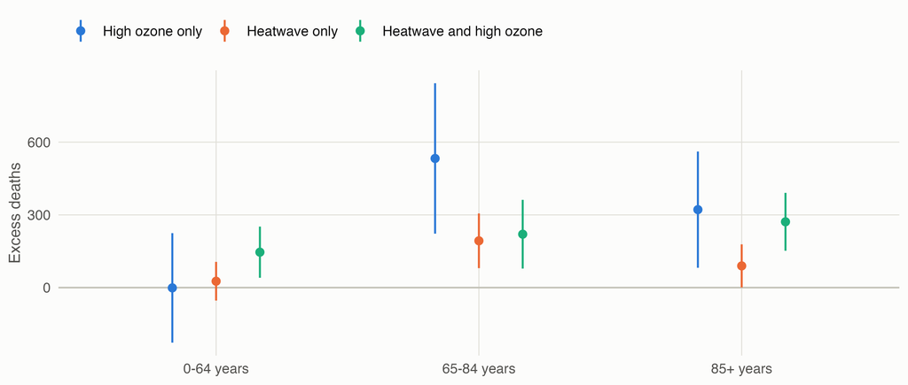

Figure 7: Excess non-accidental deaths by age group and exposure category, lag 0. Bars are 95% confidence intervals.

```r
by_age <- main[level == "age_group" & category != "any"]
by_age[, `:=`(category = category_factor(category),
              age = factor(paste(age_group, "years"), levels = paste(age_labels, "years")))]
ggplot(by_age, aes(age, excess, colour = category)) +
  geom_hline(yintercept = 0, colour = ink$axis) +
  geom_pointrange(aes(ymin = excess_low, ymax = excess_high), position = position_dodge(width = 0.5),
                  linewidth = 0.6, size = 0.35) +
  scale_colour_manual(values = colour_compound[levels(by_age$category)]) +
  labs(x = NULL, y = "Excess deaths", colour = NULL)
```

```r
age_table <- estimates[level == "age_group" & lag == lag_main & category == "any"]
age_table[, `:=`(cause = cause_labels[outcome], excess_ci = ci(excess, excess_low, excess_high))]
kable(age_table[, .(cause, age_group, deaths_total, excess_ci, excess_pct_of_deaths)],
      digits = c(0, 0, 0, 0, 2), format.args = list(big.mark = ","),
      col.names = c("Cause", "Age group", "Deaths, all days", "Excess deaths (95% CI)",
                    "% of all deaths"))
```

Table 12: Excess deaths by age group, any of the three categories.

| Cause | Age group | Deaths, all days | Excess deaths (95% CI) | % of all deaths |
| --- | --- | --- | --- | --- |
| Cardiopulmonary | 0-64 | 8,842 | -60 (-199 to 80) | -0.67 |
| Cardiopulmonary | 65-84 | 23,758 | 398 (158 to 639) | 1.68 |
| Cardiopulmonary | 85+ | 19,412 | 124 (-90 to 338) | 0.64 |
| Non-accidental | 0-64 | 34,566 | 171 (-113 to 455) | 0.50 |
| Non-accidental | 65-84 | 62,527 | 946 (556 to 1,337) | 1.51 |
| Non-accidental | 85+ | 38,266 | 683 (373 to 992) | 1.78 |

### 2.3.2 By year

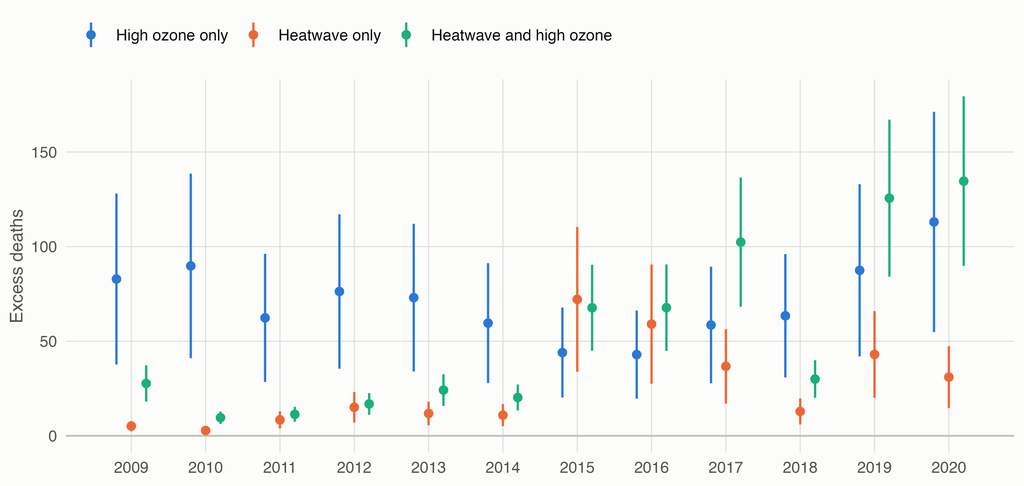

Figure 8: Excess non-accidental deaths by calendar year and exposure category, lag 0. Bars are 95% confidence intervals.

```r
by_year <- main[level == "year" & category != "any"]
by_year[, category := category_factor(category)]
ggplot(by_year, aes(year, excess, colour = category)) +
  geom_hline(yintercept = 0, colour = ink$axis) +
  geom_pointrange(aes(ymin = excess_low, ymax = excess_high), position = position_dodge(width = 0.6),
                  linewidth = 0.6, size = 0.3) +
  scale_colour_manual(values = colour_compound[levels(by_year$category)]) +
  scale_x_continuous(breaks = unique(by_year$year)) +
  labs(x = NULL, y = "Excess deaths", colour = NULL)
```

```r
year_days <- dcast(main[level == "year" & category != "any"], year ~ category,
                   value.var = "exposure_days")
year_any <- main[level == "year" & category == "any",
                 .(year, excess_ci = ci(excess, excess_low, excess_high), excess_per_100k)]
year_table <- merge(year_days[, .(year, e01, e10, e11)], year_any, by = "year")
year_table[, year := as.character(year)]
kable(year_table, digits = c(0, 0, 0, 0, 0, 2), format.args = list(big.mark = ","),
      col.names = c("Year", "Days, high ozone only", "Days, heatwave only", "Days, both",
                    "Excess deaths, any (95% CI)", "Per 100,000 inhabitants"))
```

Table 13: Exposed municipality-days and excess non-accidental deaths by year.

| Year | Days, high ozone only | Days, heatwave only | Days, both | Excess deaths, any (95% CI) | Per 100,000 inhabitants |
| --- | --- | --- | --- | --- | --- |
| 2009 | 1,318 | 37 | 145 | 116 (68 to 164) | 2.03 |
| 2010 | 1,358 | 17 | 46 | 102 (53 to 152) | 1.78 |
| 2011 | 918 | 64 | 56 | 82 (47 to 118) | 1.42 |
| 2012 | 1,131 | 108 | 76 | 108 (65 to 152) | 1.85 |
| 2013 | 1,083 | 75 | 117 | 109 (67 to 151) | 1.85 |
| 2014 | 838 | 76 | 93 | 91 (56 to 125) | 1.53 |
| 2015 | 592 | 452 | 311 | 184 (129 to 239) | 3.08 |
| 2016 | 548 | 409 | 297 | 170 (120 to 220) | 2.81 |
| 2017 | 845 | 242 | 461 | 198 (142 to 253) | 3.22 |
| 2018 | 854 | 88 | 138 | 106 (69 to 143) | 1.69 |
| 2019 | 1,162 | 264 | 541 | 256 (183 to 329) | 3.96 |
| 2020 | 1,478 | 195 | 576 | 279 (196 to 361) | 4.20 |

```r
frequency <- read_table("compound_frequency_by_year.csv")[heatwave == heatwave_main & year == 2016]
high_share <- function(flag) frequency[ozone == flag, 100 * (e01 + e11) / days]
main_flag <- paste0(get_param("air_pollution", "ozone_series_main"), "_",
                    get_param("air_pollution", "interpolation_method_main"), "_gt_p", cutoff_main)
rebuilt_flag <- sub("^o3_", "o3obs_", main_flag)
```

The years differ through the number of exposed days and the baseline mortality, not through the odds ratios, which are the same in every year. Heatwave days are several times more frequent from 2015 on, except in 2018. In 2016 the delivered ozone series flags 17% of the municipality-days as high ozone, against 28% in the series rebuilt from the validated hourly records (validation of the ozone exposure), which moves days of that year from “both” to “heatwave only”.

### 2.3.3 By municipality

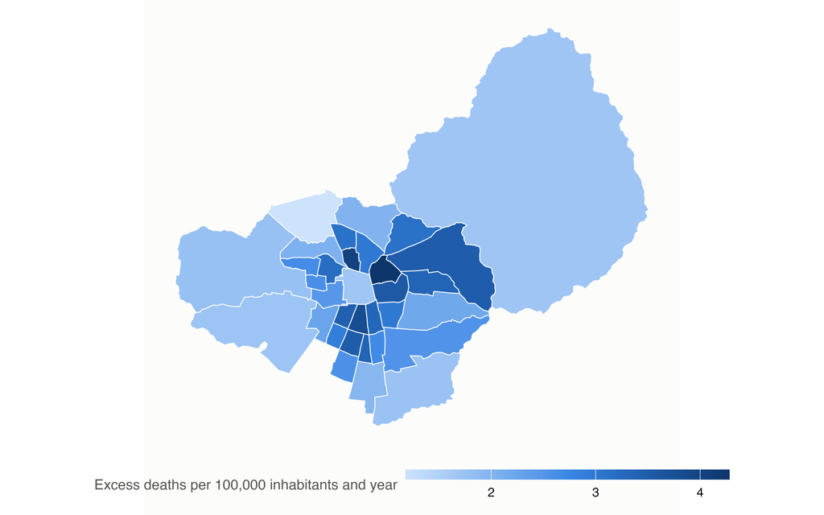

Figure 9: Excess non-accidental deaths per 100,000 inhabitants and year, any of the three categories, lag 0.

```r
polygons <- st_read(derived_path("municipality_polygons.geojson"), quiet = TRUE)
by_municipality <- main[level == "municipality" & category == "any"]
map_data <- merge(polygons, by_municipality[, .(com, excess_per_100k)], by = "com")
stopifnot(nrow(map_data) == nrow(by_municipality))
ggplot(map_data) +
  geom_sf(aes(fill = excess_per_100k), colour = ink$surface, linewidth = 0.3) +
  scale_fill_magnitude(name = "Excess deaths per 100,000 inhabitants and year") +
  theme_map()
```

```r
m <- by_municipality[order(-excess_per_100k),
                     .(municipality, exposure_days, deaths_total,
                       excess_ci = ci(excess, excess_low, excess_high), excess_pct_of_deaths,
                       excess_per_100k)]
kable(m, digits = c(0, 0, 0, 0, 2, 2), format.args = list(big.mark = ","),
      col.names = c("Municipality", "Exposed days", "Deaths, all days", "Excess deaths (95% CI)",
                    "% of all deaths", "Per 100,000 inhabitants and year"))
```

Table 14: Excess non-accidental deaths by municipality, 2009-2020, any of the three categories, ordered by rate.

| Municipality | Exposed days | Deaths, all days | Excess deaths (95% CI) | % of all deaths | Per 100,000 inhabitants and year |
| --- | --- | --- | --- | --- | --- |
| Providencia | 513 | 4,949 | 73 (50 to 96) | 1.48 | 4.28 |
| Independencia | 528 | 3,643 | 49 (33 to 65) | 1.34 | 4.02 |
| San Miguel | 507 | 3,616 | 50 (34 to 66) | 1.39 | 3.81 |
| Ñuñoa | 511 | 6,039 | 92 (64 to 120) | 1.52 | 3.56 |
| La Cisterna | 516 | 2,928 | 40 (27 to 52) | 1.36 | 3.49 |
| Las Condes | 530 | 7,634 | 124 (87 to 161) | 1.63 | 3.48 |
| Pedro Aguirre Cerda | 509 | 3,487 | 45 (30 to 60) | 1.29 | 3.44 |
| La Reina | 512 | 2,545 | 39 (28 to 51) | 1.55 | 3.36 |
| San Ramón | 511 | 2,789 | 36 (24 to 48) | 1.29 | 3.35 |
| San Joaquín | 508 | 2,961 | 40 (27 to 52) | 1.34 | 3.31 |
| Quinta Normal | 506 | 3,442 | 45 (31 to 60) | 1.31 | 3.20 |
| Vitacura | 518 | 2,165 | 33 (23 to 43) | 1.53 | 3.12 |
| Conchalí | 517 | 3,804 | 51 (34 to 67) | 1.33 | 3.11 |
| Recoleta | 524 | 4,554 | 59 (40 to 78) | 1.29 | 2.98 |
| Macul | 513 | 3,030 | 44 (30 to 57) | 1.45 | 2.98 |
| Lo Espejo | 511 | 3,071 | 37 (24 to 50) | 1.20 | 2.88 |
| La Granja | 508 | 3,157 | 40 (27 to 53) | 1.27 | 2.67 |
| Cerro Navia | 514 | 3,715 | 45 (29 to 61) | 1.21 | 2.64 |
| Lo Prado | 510 | 2,652 | 32 (21 to 43) | 1.21 | 2.60 |
| El Bosque | 517 | 4,241 | 53 (35 to 72) | 1.26 | 2.57 |
| La Florida | 510 | 8,377 | 117 (81 to 153) | 1.40 | 2.53 |
| Estación Central | 502 | 3,610 | 44 (29 to 59) | 1.22 | 2.46 |
| Cerrillos | 518 | 1,871 | 23 (15 to 30) | 1.21 | 2.25 |
| Peñalolén | 508 | 4,941 | 66 (45 to 87) | 1.33 | 2.19 |
| Renca | 519 | 3,198 | 37 (24 to 51) | 1.17 | 2.04 |
| Huechuraba | 519 | 1,863 | 24 (16 to 32) | 1.29 | 2.00 |
| La Pintana | 495 | 3,694 | 44 (27 to 61) | 1.19 | 1.94 |
| Pudahuel | 534 | 4,159 | 50 (31 to 68) | 1.20 | 1.77 |
| Puente Alto | 506 | 9,669 | 124 (82 to 166) | 1.28 | 1.74 |
| Maipú | 516 | 9,306 | 112 (73 to 151) | 1.20 | 1.72 |
| Lo Barnechea | 540 | 1,344 | 21 (15 to 28) | 1.59 | 1.69 |
| Santiago | 520 | 6,314 | 82 (55 to 109) | 1.29 | 1.69 |
| Quilicura | 539 | 2,591 | 30 (17 to 42) | 1.14 | 1.18 |

**NoteHow to read the map**

Every municipality has the same odds ratios, so the map is not a map of vulnerability to heat or ozone. A municipality has a higher rate when it has more deaths per inhabitant on ordinary days, which mostly reflects an older population, or more exposed days. Rates are crude, not standardised by age.

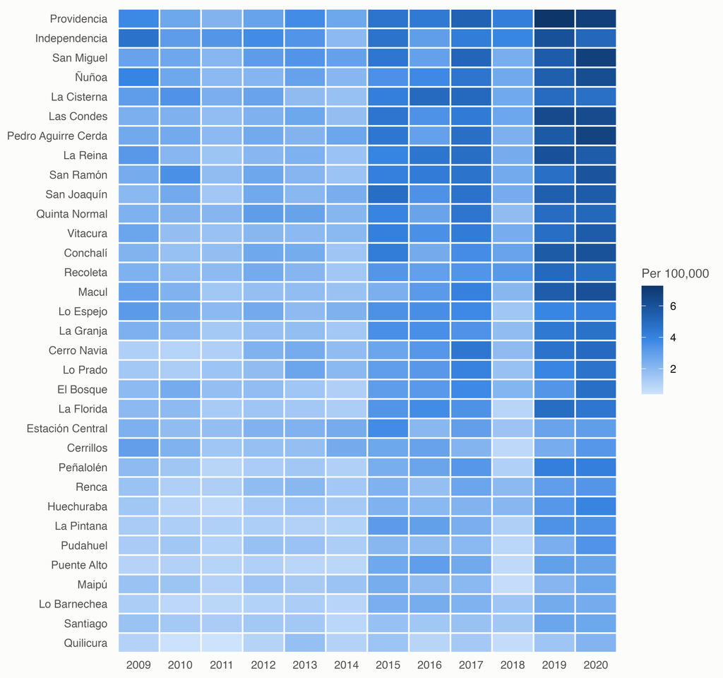

Figure 10: Excess non-accidental deaths per 100,000 inhabitants by municipality and year, any of the three categories. Municipalities ordered by their rate over the whole period.

```r
my <- main[level == "municipality_year" & category == "any"]
my[, municipality := factor(municipality, levels = rev(by_municipality[order(-excess_per_100k), municipality]))]
ggplot(my, aes(factor(year), municipality, fill = excess_per_100k)) +
  geom_tile(colour = ink$surface, linewidth = 0.6) +
  scale_fill_magnitude(name = "Per 100,000") +
  labs(x = NULL, y = NULL) +
  theme(panel.grid.major = element_blank(), legend.position = "right",
        legend.justification = "center")
```

The table by municipality, year, category and age group is `Output/Tables/burden_estimates.csv` (`level` is `municipality_year`).

## 2.4 Baseline mortality and population

```r
b <- baseline[outcome == "non_accidental" & lag == lag_main]
# Pooled rate: deaths on E00 days over the person-days at risk on those days
b_summary <- b[, .(deaths = sum(reference_deaths),
                   rate = 1e5 * sum(reference_deaths) / sum(reference_days * population),
                   lowest = min(baseline_daily_rate_per_100k),
                   highest = max(baseline_daily_rate_per_100k)), by = rate_age_group]
kable(b_summary[, .(rate_age_group, deaths, rate, lowest, highest)],
      digits = c(0, 0, 3, 3, 3), format.args = list(big.mark = ","),
      col.names = c("Age group", "Deaths on E00 days", "Rate, all municipalities and years",
                    "Lowest municipality-year", "Highest municipality-year"))
```

Table 15: Baseline mortality on days with neither exposure, non-accidental deaths, lag 0: deaths per 100,000 inhabitants of the age group and day.

| Age group | Deaths on E00 days | Rate, all municipalities and years | Lowest municipality-year | Highest municipality-year |
| --- | --- | --- | --- | --- |
| 0-64 | 24,623 | 0.351 | 0.099 | 0.718 |
| 65+ | 70,876 | 8.805 | 4.875 | 18.817 |

The population comes from the INE projections by municipality, sex and single year of age (base 2017). They give single years up to 79 and one group for 80 years or more, so the age groups 65-84 and 85 or more of the plan have no population at municipal level. Excess deaths by those age groups are not affected, because the population cancels out of the formula; rates per 100,000 are given for 0-64 and 65 or more, and for the whole population. `Output/Tables/burden_baseline_rates.csv` has the baseline rate of every municipality, year and age group.

## 2.5 Other lags

```r
lag_table <- estimates[level == "total" & or_source == "age-specific" & category == "any"]
lag_table[, `:=`(cause = factor(cause_labels[outcome], levels = cause_labels[unique(outcome)]),
                 excess_ci = ci(excess, excess_low, excess_high))]
wide <- dcast(lag_table, lag ~ cause, value.var = "excess_ci")
kable(wide, col.names = c("Lag", names(wide)[-1]))
```

Table 16: Excess deaths, any of the three categories, by lag of the exposure (one lag per model).

| Lag | Cardiopulmonary | Non-accidental |
| --- | --- | --- |
| 0 | 463 (112 to 814) | 1,800 (1,227 to 2,374) |
| 1 | 454 (102 to 807) | 1,444 (872 to 2,017) |
| 2 | 49 (-297 to 396) | 503 (-60 to 1,066) |
| 3 | 1 (-345 to 347) | 86 (-474 to 646) |

Each lag is a separate model, and exposures on consecutive days are correlated: the rows are not additive across lags. The analysis of the lag structure fits all the lags together.

## 2.6 Two estimates and two sets of odds ratios

```r
compare <- estimates[outcome == "non_accidental" & level == "total" & lag == lag_main]
compare[, `:=`(category = category_all(category),
               plan = ci(excess, excess_low, excess_high),
               fraction = ci(attributable, attributable_low, attributable_high))]
setorder(compare, or_source, category)
kable(compare[, .(or_source, category, plan, fraction)],
      col.names = c("Odds ratios", "Category", "Plan: baseline x (OR - 1) x days",
                    "Observed deaths x (OR - 1) / OR"))
```

Table 17: Formula of the plan against the attributable fraction among the exposed, and odds ratios by age group against one odds ratio for all ages. Non-accidental deaths, lag 0.

| Odds ratios | Category | Plan: baseline x (OR - 1) x days | Observed deaths x (OR - 1) / OR |
| --- | --- | --- | --- |
| age-specific | High ozone only | 853 (401 to 1,306) | 854 (415 to 1,293) |
| age-specific | Heatwave only | 309 (145 to 473) | 311 (156 to 466) |
| age-specific | Heatwave and high ozone | 638 (425 to 851) | 644 (448 to 840) |
| age-specific | Any of the three | 1,800 (1,227 to 2,374) | 1,809 (1,260 to 2,358) |
| all ages | High ozone only | 854 (402 to 1,307) | 855 (416 to 1,294) |
| all ages | Heatwave only | 308 (143 to 472) | 310 (155 to 465) |
| all ages | Heatwave and high ozone | 637 (424 to 850) | 642 (446 to 838) |
| all ages | Any of the three | 1,799 (1,225 to 2,372) | 1,807 (1,258 to 2,356) |

```r
ratio <- estimates[level == "municipality_year" & or_source == "age-specific" & lag == lag_main &
                     outcome == "non_accidental" & category == "any", attributable / excess]
```

The two estimates agree in the total and differ by municipality and year, where the deaths observed on the few exposed days are a small number: the ratio of the second to the first ranges from 0.59 to 1.74 across the 396 municipality-years. One odds ratio for all ages gives the same total as the odds ratios by age group.

## 2.7 Limits

- The odds ratios are those of the unadjusted compound model, one lag at a time. Adjusting for PM2.5, nitrogen dioxide and humidity lowers them (sensitivity analyses).
- Intervals reflect the uncertainty of the odds ratios only.
- The odds ratio of a category is the same for every municipality and year. Differences between municipalities come from baseline mortality and exposed days.
- An interval that includes zero in one age group or category does not make the excess zero; the estimates are added as they are, negative values included.
- The interaction is not significant in the models, so the excess on days with both exposures is what the two single excesses add up to, within the uncertainty of the data.

# 3 Continued in deliverable 4

- Sensitivity analyses: adjustment for PM2.5, nitrogen dioxide, humidity and temperature, three ozone levels, alternative ozone series.
- Lag structure: all the lags in one model, and the distributed lag non-linear model of temperature.

Not done: the mediation of the heatwave effect by ozone (secondary aim of the plan), and the choice of the primary lag and of the headline definitions, which belong to the principal investigator.

# 4 R scripts

The scripts are in [`Code/`](https://github.com/AmaruSimonAgueroJimenez/Heatwave-ozone-mortality-Chile/tree/main/Code) of the repository. They are not executed when this page is rendered: `Code/run_all.R` runs them in order and this page reads their outputs. The code of each one is folded below.

| Script | Purpose |
| --- | --- |
| `Code/30_models_main.R` | Conditional logistic regression, compound exposure and additive interaction, by cause, age and sex, and over the grid of definitions. |
| `Code/31_attributable_burden.R` | Excess deaths attributable to heatwave only, high ozone only and both, by municipality, year and age group. |

**Code/30_models_main.R**

```r
# 30_models_main.R
# Conditional logistic regression of the case-crossover dataset: single
# exposures, joint model, four-category compound exposure and additive
# interaction (REOI, AP, S).
#
# Inputs
#   Data/Derived/case_crossover.csv    (script 21)
#   Data/Derived/exposure_lagged.csv   (script 21)
# Outputs
#   Output/Tables/models_main_or.csv             odds ratios, headline definition
#   Output/Tables/models_main_interaction.csv    REOI, AP, S, headline definition
#   Output/Tables/models_grid.csv                compound model over the definition grid
#   Output/Tables/models_ozone_continuous.csv    ozone per 10 ppb
#
# Models, for each outcome, subgroup and single-day lag (0 to 3):
#   heatwave   logit P = b1 HW
#   ozone      logit P = b2 O3high
#   joint      logit P = b1 HW + b2 O3high
#   compound   logit P = b10 E10 + b01 E01 + b11 E11        (reference E00)
# The compound model is the joint model with its interaction term written as
# categories: OR11 / (OR10 x OR01) is the multiplicative interaction.
#
# The fits use one row per municipality, day of death and referent day,
# weighted by the number of deaths; tests/test_methods.R shows this equals the
# fit on the individual records.

suppressPackageStartupMessages(library(survival))
source(here::here("Code", "00_setup.R"))
source(here::here("Code", "01_functions.R"))

conf_level <- get_param("models", "conf_level")
lags <- unlist(get_param("design", "lags_days"))
heatwave_main <- get_param("models", "heatwave_main")
ozone_main <- paste0(get_param("air_pollution", "ozone_series_main"), "_",
                     get_param("air_pollution", "interpolation_method_main"))
ozone_flag_main <- paste0(ozone_main, "_gt_p", get_param("models", "ozone_cutoff_main"))
outcomes <- names(get_param("mortality", "cause_groups"))
age_labels <- unlist(get_param("mortality", "age_labels"))

cc <- fread(derived_path("case_crossover.csv"), encoding = "UTF-8")
cc[, `:=`(date = as.Date(date), case_date = as.Date(case_date))]
lagged <- fread(derived_path("exposure_lagged.csv"), encoding = "UTF-8")
lagged[, date := as.Date(date)]
stopifnot(all(c(paste0(heatwave_main, "_lag", lags), paste0(ozone_flag_main, "_lag", lags))
              %in% names(lagged)))

# The datasets and the compound model come from Code/01_functions.R, shared
# with the burden, sensitivity and distributed-lag scripts.
prepare <- function(outcome, subgroup) {
  prepare_model_data(cc, lagged, outcome, subgroup, age_labels)
}
with_exposure <- function(collapsed, heatwave, ozone_flag, lag) {
  attach_compound_exposure(collapsed, lagged, heatwave, ozone_flag, lag)
}

# ---- 1. Headline definition: all outcomes, subgroups and lags ----------------

subgroups <- c("all", age_labels, "male", "female")
main_jobs <- CJ(outcome = outcomes, subgroup = subgroups, sorted = FALSE)

run_main <- function(i) {
  outcome <- main_jobs$outcome[i]
  subgroup <- main_jobs$subgroup[i]
  collapsed <- prepare(outcome, subgroup)
  or_list <- list()
  interaction_list <- list()
  for (lag in lags) {
    d <- with_exposure(collapsed, heatwave_main, ozone_flag_main, lag)
    counts <- category_deaths(d)
    label <- data.table(outcome = outcome, subgroup = subgroup, lag = lag)
    # A category with no deaths on the day of death has no estimable odds ratio
    estimable <- all(unlist(counts[, .(deaths_e10, deaths_e01, deaths_e11)]) > 0)
    logged <- with_warnings(list(
      single = rbind(
        cbind(model = "heatwave", odds_ratios(fit_conditional_logit(d, "hw"), conf_level)),
        cbind(model = "ozone", odds_ratios(fit_conditional_logit(d, "oz"), conf_level)),
        cbind(model = "joint", odds_ratios(fit_conditional_logit(d, c("hw", "oz")), conf_level))
      ),
      compound = if (estimable) compound_results(d, conf_level)
    ))
    fit_warnings <- paste(unique(logged$warnings), collapse = " | ")
    or_rows <- logged$value$single
    if (estimable) {
      or_rows <- rbind(or_rows, cbind(model = "compound", logged$value$compound$or))
      interaction_list[[length(interaction_list) + 1]] <- cbind(
        label, logged$value$compound$interaction, counts, fit_warnings = fit_warnings
      )
    }
    or_list[[length(or_list) + 1]] <- cbind(label, or_rows, counts, fit_warnings = fit_warnings)
  }
  list(or = rbindlist(or_list), interaction = rbindlist(interaction_list))
}
main_results <- run_parallel(seq_len(nrow(main_jobs)), run_main, "Model run")
main_or <- rbindlist(lapply(main_results, `[[`, "or"))
main_interaction <- rbindlist(lapply(main_results, `[[`, "interaction"))
main_or[, `:=`(heatwave = heatwave_main, ozone = ozone_flag_main)]
main_interaction[, `:=`(heatwave = heatwave_main, ozone = ozone_flag_main)]
fwrite(main_or, file.path(dir_tables, "models_main_or.csv"))
fwrite(main_interaction, file.path(dir_tables, "models_main_interaction.csv"))

# ---- 2. Definition grid: compound model, two outcomes, all lags --------------

heatwaves <- unique(sub("_lag[0-9]+$", "", grep("^hw_", names(lagged), value = TRUE)))
ozone_flags <- unique(sub("_lag[0-9]+$", "", grep("_gt_p[0-9]+_lag", names(lagged), value = TRUE)))
grid_outcomes <- c("non_accidental", "cardiopulmonary")
grid_jobs <- CJ(outcome = grid_outcomes, heatwave = heatwaves, ozone = ozone_flags, sorted = FALSE)
grid_data <- lapply(setNames(grid_outcomes, grid_outcomes), prepare, subgroup = "all")

run_grid <- function(i) {
  job <- grid_jobs[i]
  rbindlist(lapply(lags, function(lag) {
    d <- with_exposure(grid_data[[job$outcome]], job$heatwave, job$ozone, lag)
    counts <- category_deaths(d)
    # A category with no deaths on the day of death has no estimable odds ratio
    if (any(unlist(counts[, .(deaths_e10, deaths_e01, deaths_e11)]) == 0)) {
      return(cbind(job, lag = lag, counts, estimable = FALSE))
    }
    logged <- with_warnings(compound_results(d, conf_level))
    compound <- logged$value
    or <- dcast(compound$or[, .(term, or, or_low, or_high)], . ~ term,
                value.var = c("or", "or_low", "or_high"))[, !"."]
    measures <- dcast(compound$interaction[, .(measure = gsub(" ", "_", tolower(measure)),
                                               estimate, low, high)],
                      . ~ measure, value.var = c("estimate", "low", "high"))[, !"."]
    cbind(job, lag = lag, counts, estimable = TRUE, or, measures,
          fit_warnings = paste(unique(logged$warnings), collapse = " | "))
  }), fill = TRUE)
}
grid_results <- run_parallel(seq_len(nrow(grid_jobs)), run_grid, "Grid run")
fwrite(rbindlist(grid_results, fill = TRUE), file.path(dir_tables, "models_grid.csv"))

# ---- 3. Ozone as a continuous exposure, per 10 ppb ---------------------------

ozone_series <- as.vector(outer(c("o3", "o3obs", "o3mda8"), c("idw", "ok"), paste, sep = "_"))
continuous <- rbindlist(lapply(grid_outcomes, function(outcome) {
  collapsed <- grid_data[[outcome]]
  rbindlist(lapply(ozone_series, function(series) rbindlist(lapply(lags, function(lag) {
    d <- copy(collapsed)
    d[, ozone_10ppb := lagged[[paste0(series, "_lag", lag)]][exposure_row] / 10]
    d[, hw := lagged[[paste0(heatwave_main, "_lag", lag)]][exposure_row]]
    complete <- d[, .(ok = !anyNA(ozone_10ppb) && !anyNA(hw)), by = stratum][ok == TRUE, stratum]
    d <- d[stratum %in% complete]
    rbind(
      cbind(outcome = outcome, series = series, lag = lag, adjustment = "none",
            odds_ratios(fit_conditional_logit(d, "ozone_10ppb"), conf_level)),
      cbind(outcome = outcome, series = series, lag = lag, adjustment = heatwave_main,
            odds_ratios(fit_conditional_logit(d, c("ozone_10ppb", "hw")), conf_level))
    )[term == "ozone_10ppb"]
  }))))
}))
fwrite(continuous, file.path(dir_tables, "models_ozone_continuous.csv"))

message("Models written: ", nrow(main_or), " odds ratios (headline), ",
        nrow(grid_jobs) * length(lags), " grid fits")
```

**Code/31_attributable_burden.R**

```r
# 31_attributable_burden.R
# Deaths attributable to heatwave only, high ozone only and both together.
#
# Inputs
#   Data/Derived/case_crossover.csv, exposure_lagged.csv   (script 21)
#   Data/Derived/exposure_2009_2020.csv                    (script 13)
#   Output/Tables/models_main_or.csv                       (script 30)
#   inputs$population                                      INE projections
# Outputs
#   Output/Tables/burden_estimates.csv        excess deaths by level of aggregation
#   Output/Tables/burden_odds_ratios.csv      odds ratios the burden is computed with
#   Output/Tables/burden_baseline_rates.csv   baseline daily mortality per 100,000
#   Output/Tables/burden_population.csv       population by municipality and year
#
# Formula of the analysis plan, for municipality i, calendar year t, age group j
# and exposure category c (E10 heatwave only, E01 high ozone only, E11 both):
#   ED = Population x Age proportion x Baseline daily rate x (OR - 1) x Exposure days
# The baseline daily rate is the deaths per inhabitant and day on the days of
# the warm season with neither exposure (E00). The first three factors
# multiply to the deaths per day on E00 days, so the population cancels out:
#   ED = (deaths on E00 days / E00 days) x (OR - 1) x days in category c
# This is what the script computes (`excess`). The population only enters the
# rates per 100,000. tests/test_methods.R checks the identity.
#
# A second estimate (`attributable`) applies the attributable fraction among
# the exposed, (OR - 1) / OR, to the deaths observed on the exposed days. It
# does not rely on E00 days having the same baseline mortality as the exposed
# days, which fall in different weeks of the season.
#
# The odds ratios are those of the compound model of script 30, refitted here
# to obtain their covariance; the script stops if they differ from the table
# written by script 30.

suppressPackageStartupMessages(library(survival))
source(here::here("Code", "00_setup.R"))
source(here::here("Code", "01_functions.R"))

conf_level <- get_param("models", "conf_level")
lags <- unlist(get_param("design", "lags_days"))
outcomes <- unlist(get_param("burden", "outcomes"))
heatwave_main <- get_param("models", "heatwave_main")
ozone_flag_main <- paste0(get_param("air_pollution", "ozone_series_main"), "_",
                          get_param("air_pollution", "interpolation_method_main"),
                          "_gt_p", get_param("models", "ozone_cutoff_main"))
age_labels <- unlist(get_param("mortality", "age_labels"))
study_years <- unlist(get_param("study", "years"))
open_age <- get_param("population", "open_age")
rate_breaks <- unlist(get_param("population", "rate_age_breaks"))
rate_labels <- unlist(get_param("population", "rate_age_labels"))
municipalities <- study_municipalities()
categories <- c("e10", "e01", "e11")

cc <- fread(derived_path("case_crossover.csv"), encoding = "UTF-8")
cc[, `:=`(date = as.Date(date), case_date = as.Date(case_date))]
lagged <- fread(derived_path("exposure_lagged.csv"), encoding = "UTF-8")
lagged[, date := as.Date(date)]
exposure <- fread(derived_path("exposure_2009_2020.csv"), encoding = "UTF-8",
                  select = c("com", "date", "year", "in_study_period", "warm_season",
                             heatwave_main, ozone_flag_main))
exposure[, date := as.Date(date)]
main_or <- fread(file.path(dir_tables, "models_main_or.csv"))

# ---- 1. Exposure category of every warm-season day, by lag ------------------

# Category of the day `lag` days before each warm-season day of the study
all_lagged <- lagged_exposure(exposure[, c("com", "date", heatwave_main, ozone_flag_main),
                                       with = FALSE],
                              c(heatwave_main, ozone_flag_main), lags)
study_days <- exposure[in_study_period == TRUE & warm_season == TRUE, .(com, date, year)]
stopifnot(nrow(study_days) == nrow(municipalities) * uniqueN(study_days$date))
days <- rbindlist(lapply(lags, function(lag) {
  x <- all_lagged[study_days, on = .(com, date)]
  hw <- x[[paste0(heatwave_main, "_lag", lag)]]
  oz <- x[[paste0(ozone_flag_main, "_lag", lag)]]
  x[, .(com, date, year, lag = lag,
        category = fcase(hw == 0 & oz == 0, "e00", hw == 1 & oz == 0, "e10",
                         hw == 0 & oz == 1, "e01", hw == 1 & oz == 1, "e11"))]
}))
# The same values as the lagged exposures the models use
check <- merge(days[lag == lags[1]], lagged[, c("com", "date", paste0(heatwave_main, "_lag", lags[1]),
                                                paste0(ozone_flag_main, "_lag", lags[1])), with = FALSE],
               by = c("com", "date"))
setnames(check, 6:7, c("hw", "oz"))
stopifnot(nrow(check) > 0,
          check[, all((category %in% c("e10", "e11")) == (hw == 1), na.rm = TRUE)],
          check[, all((category %in% c("e01", "e11")) == (oz == 1), na.rm = TRUE)])
missing_days <- days[is.na(category), .N, by = lag]

# ---- 2. Odds ratios and expected deaths by age group -------------------------

# Deaths expected and observed on the exposed days, by municipality and year
burden_cells <- function(case_rows, lag_value) {
  deaths <- case_rows[, .(n = .N), by = .(com, date = case_date)]
  x <- merge(days[lag == lag_value], deaths, by = c("com", "date"), all.x = TRUE)
  x[is.na(n), n := 0L]
  stopifnot(sum(x$n) == nrow(case_rows))   # every death falls on a study day
  counts <- x[!is.na(category), .(days = .N, deaths = sum(n)), by = .(com, year, category)]
  reference <- counts[category == "e00", .(com, year, reference_days = days,
                                           reference_deaths = deaths)]
  out <- merge(CJ(com = municipalities$code, year = study_years[1]:study_years[2],
                  category = categories),
               counts, by = c("com", "year", "category"), all.x = TRUE)
  out[is.na(days), `:=`(days = 0L, deaths = 0L)]
  out <- merge(out, reference, by = c("com", "year"), all.x = TRUE)
  # A baseline needs days with neither exposure in every municipality and year
  stopifnot(!anyNA(out$reference_days), all(out$reference_days > 0))
  out[, `:=`(expected = reference_deaths / reference_days * days, observed = deaths,
             deaths_no_category = x[is.na(category), sum(n)])]
  out[]
}
```

```r
fit_group <- function(outcome_value, subgroup_value, lag_value) {
  collapsed <- prepare_model_data(cc, lagged, outcome_value, subgroup_value, age_labels)
  d <- attach_compound_exposure(collapsed, lagged, heatwave_main, ozone_flag_main, lag_value)
  result <- compound_results(d, conf_level)
  beta <- coef(result$fit)[categories]
  # Same estimates as script 30
  reference <- main_or[outcome == outcome_value & subgroup == subgroup_value &
                         lag == lag_value & model == "compound"][match(categories, term)]
  stopifnot(nrow(reference) == 3, max(abs(reference$log_or - beta)) < 1e-8)
  case_rows <- cc[select_case_rows(cc, outcome_value, subgroup_value, age_labels) & case == 1]
  list(beta = beta, covariance = vcov(result$fit)[categories, categories],
       or = cbind(outcome = outcome_value, subgroup = subgroup_value, lag = lag_value, result$or),
       cells = cbind(outcome = outcome_value, age_group = subgroup_value, lag = lag_value,
                     burden_cells(case_rows, lag_value)),
       deaths = cbind(outcome = outcome_value, age_group = subgroup_value, lag = lag_value,
                      case_rows[, .(deaths_total = .N), by = .(com, year = year(case_date))]))
}

jobs <- CJ(outcome = outcomes, subgroup = c(age_labels, "all"), lag = lags, sorted = FALSE)
fits <- lapply(seq_len(nrow(jobs)), function(i) fit_group(jobs$outcome[i], jobs$subgroup[i],
                                                          jobs$lag[i]))
odds_table <- rbindlist(lapply(fits, `[[`, "or"))
fwrite(odds_table, file.path(dir_tables, "burden_odds_ratios.csv"))
cells <- rbindlist(lapply(fits, `[[`, "cells"))
cells <- merge(cells, municipalities, by.x = "com", by.y = "code")
setnames(cells, "name", "municipality")
# All the deaths of each outcome and age group, the denominator of the
# attributable fraction
death_totals <- rbindlist(lapply(fits, `[[`, "deaths"))
death_totals <- merge(death_totals, municipalities, by.x = "com", by.y = "code")
setnames(death_totals, "name", "municipality")

# ---- 3. Population -----------------------------------------------------------

population <- read_population(input_path("population"), municipalities$code, study_years, open_age)
population[, rate_age_group := as.character(cut(age, c(rate_breaks, Inf), labels = rate_labels,
                                                right = FALSE))]
stopifnot(!anyNA(population$rate_age_group))
population_table <- dcast(population, com + year ~ rate_age_group, value.var = "population",
                          fun.aggregate = sum)
population_table[, total := rowSums(.SD), .SDcols = rate_labels]
population_table <- merge(municipalities, population_table, by.x = "code", by.y = "com")
setnames(population_table, c("code", "name"), c("com", "municipality"))
fwrite(population_table, file.path(dir_tables, "burden_population.csv"))

# ---- 4. Excess deaths by level of aggregation --------------------------------

levels_by <- list(total = character(0), age_group = "age_group", year = "year",
                  municipality = c("com", "municipality"),
                  municipality_year = c("com", "municipality", "year"))
exposure_days <- function(lag_value, by) {
  counts <- days[lag == lag_value & category %in% categories]
  counts <- merge(counts, municipalities, by.x = "com", by.y = "code")
  setnames(counts, "name", "municipality")
  by <- setdiff(by, "age_group")
  rbind(counts[, .(exposure_days = .N), by = c(by, "category")],
        counts[, .(category = "any", exposure_days = .N), by = by])
}
person_years <- function(by) {
  by <- setdiff(by, "age_group")
  population_table[, .(population = sum(total)), by = by]
}

estimate_level <- function(outcome_value, lag_value, source, level) {
  by <- levels_by[[level]]
  if (source == "age-specific") {
    use <- cells[outcome == outcome_value & lag == lag_value & age_group %in% age_labels]
    keys <- age_labels
  } else {
    if (level == "age_group") return(NULL)
    use <- cells[outcome == outcome_value & lag == lag_value & age_group == "all"]
    keys <- "all"
  }
  models <- lapply(setNames(keys, keys), function(key) {
    fits[[which(jobs$outcome == outcome_value & jobs$subgroup == key & jobs$lag == lag_value)]][
      c("beta", "covariance")]
  })
  out <- attributable_deaths(use, models, by, conf_level)
  totals <- death_totals[outcome == outcome_value & lag == lag_value & age_group %in% keys,
                         .(deaths_total = sum(deaths_total)), by = by]
  out <- if (length(by) == 0) cbind(out, totals) else merge(out, totals, by = by, all.x = TRUE)
  out[is.na(deaths_total), deaths_total := 0L]
  out[, `:=`(excess_pct_of_deaths = 100 * excess / deaths_total,
             attributable_pct_of_deaths = 100 * attributable / deaths_total)]
  days_by <- exposure_days(lag_value, by)
  out <- merge(out, days_by, by = intersect(names(out), names(days_by)), all.x = TRUE)
  out[is.na(exposure_days), exposure_days := 0L]
  if (level != "age_group") {
    pop <- person_years(by)
    out <- if (length(by) == 0) cbind(out, pop) else merge(out, pop, by = intersect(names(out), names(pop)))
    out[, `:=`(excess_per_100k = 1e5 * excess / population,
               attributable_per_100k = 1e5 * attributable / population)]
  }
  cbind(outcome = outcome_value, lag = lag_value, or_source = source, level = level, out)
}

estimate_jobs <- CJ(outcome = outcomes, lag = lags, source = c("age-specific", "all ages"),
                    level = names(levels_by), sorted = FALSE)
estimates <- rbindlist(lapply(seq_len(nrow(estimate_jobs)), function(i) {
  estimate_level(estimate_jobs$outcome[i], estimate_jobs$lag[i], estimate_jobs$source[i],
                 estimate_jobs$level[i])
}), fill = TRUE)
setcolorder(estimates, c("outcome", "lag", "or_source", "level", "age_group", "year", "com",
                         "municipality", "category", "exposure_days", "deaths_total"))
setorder(estimates, outcome, lag, or_source, level, age_group, year, com, category, na.last = TRUE)
fwrite(estimates, file.path(dir_tables, "burden_estimates.csv"))
```

```r
# ---- 5. Baseline daily mortality per 100,000 ----------------------------------

# Deaths per day on days with neither exposure, over the population of the
# age group, for the age groups that have a denominator
baseline <- rbindlist(lapply(outcomes, function(outcome_value) rbindlist(lapply(lags, function(lag_value) {
  case_rows <- cc[select_case_rows(cc, outcome_value, "all", age_labels) & case == 1 &
                    !is.na(age_years)]
  case_rows[, rate_age_group := as.character(cut(age_years, c(rate_breaks, Inf),
                                                 labels = rate_labels, right = FALSE))]
  deaths <- case_rows[, .(n = .N), by = .(com, date = case_date, rate_age_group)]
  reference_days <- days[lag == lag_value & category == "e00"]
  x <- merge(CJ(com = municipalities$code, year = study_years[1]:study_years[2],
                rate_age_group = rate_labels),
             merge(reference_days, deaths, by = c("com", "date"))[
               , .(reference_deaths = sum(n)), by = .(com, year, rate_age_group)],
             by = c("com", "year", "rate_age_group"), all.x = TRUE)
  x[is.na(reference_deaths), reference_deaths := 0L]
  x <- merge(x, reference_days[, .(reference_days = .N), by = .(com, year)], by = c("com", "year"))
  pop <- melt(population_table, id.vars = c("com", "municipality", "year"),
              measure.vars = rate_labels, variable.name = "rate_age_group",
              value.name = "population", variable.factor = FALSE)
  x <- merge(x, pop, by = c("com", "year", "rate_age_group"))
  x[, baseline_daily_rate_per_100k := 1e5 * reference_deaths / reference_days / population]
  cbind(outcome = outcome_value, lag = lag_value, x)
}))))
setcolorder(baseline, c("outcome", "lag", "com", "municipality", "year", "rate_age_group"))
fwrite(baseline, file.path(dir_tables, "burden_baseline_rates.csv"))

if (nrow(missing_days) > 0) {
  message("Warm-season days without an exposure category, by lag:")
  print(missing_days)
}
message("Deaths on days without an exposure category: ",
        cells[, max(deaths_no_category)])
lag_main <- get_param("models", "lag_main")
print(estimates[level == "total" & lag == lag_main,
                .(outcome, or_source, category, exposure_days, observed = round(observed),
                  expected = round(expected, 1), excess = round(excess, 1),
                  excess_low = round(excess_low, 1), excess_high = round(excess_high, 1),
                  attributable = round(attributable, 1))])
```